# Various Jail Population

2022-05-20

## Introduction

From the incarceration dataset, numerous domains need to be expressed as with this assignment. The focus will be on the issue of the total jail population in different divisions, regions, and states. With the problem domain, we will review the most crucial factor of race as we will look into black, white, and other races and how each race contributes to the total jail population. As we gain information on these values through charts and maps, it allows us to gain a general view of what is happening in society and why the issue of racism and inequality is expressed all the time and has not changed throughout the years. Overall, with the assignment, it is essential to view all this information as we can learn more about how to make a better society for future generations and prevent the same results each year.

## Summary Information

```
## $num_variable
## [1] 121
##
## $division_data
##             division
## 1 East South Central
## 2            Pacific
## 3           Mountain
## 4 West South Central
## 5        New England
## 6     South Atlantic
## 7 East North Central
## 8 West North Central
## 9    Middle Atlantic
##
```

[output cut: 87 more lines]

## Bar Chart on Trends Over Time

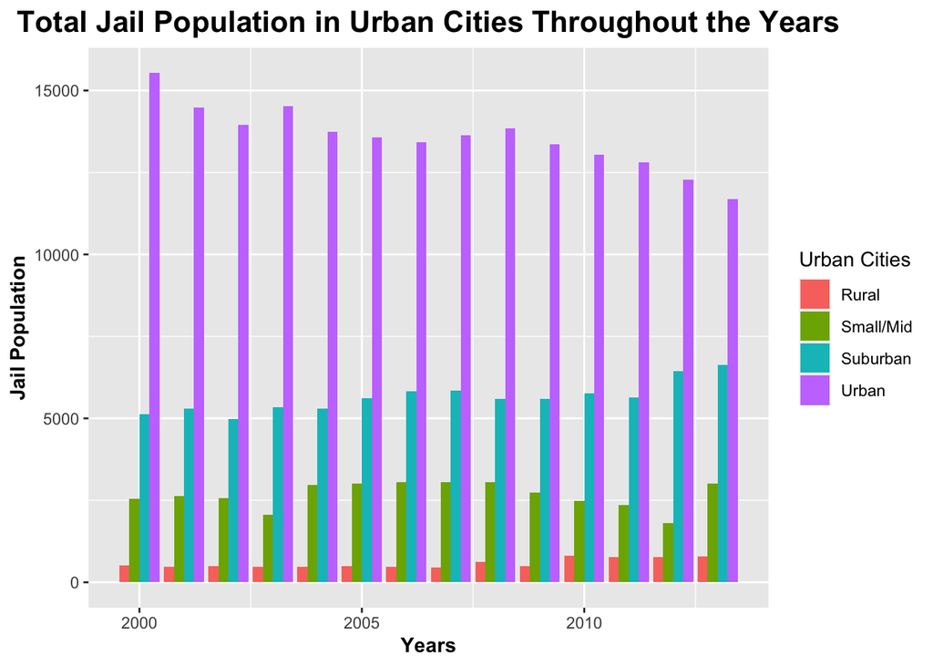

#### Observations:

The bar chart was chosen to represent the jail population throughout the years in urban cities. The chart emphasizes a trend over time in the four urban cities: rural cities, small to mid-cities, suburban cities, and urban cities captured through the dataset. We can view how different cities make a difference in the jail population with the chart. The chart shows that more populated cities have the most jail population compared to smaller cities with fewer individuals. Also, the chart emphasizes a pattern of the four urban cities being constant, with the jail population as not one area has a dramatic spike. However, we can see that urban cities’ jail population has decreased throughout the years. Finally, it gives the essential purpose of allowing people to realize that living in a smaller populated area is safer.